# Kinetic parameters

Mariana Mendoza Badillo

## Introducción

Este es un código experimental para generar un gráfico del ajuste del modelo de Michaelis-Menten con regresión no lineal por mínimos cuadrados y obtener constantes cinéticas (constante de Michaelis y velocidad máxima). Para descargar el código en R, entre en la url https://github.com/mariana-mb4/Enzyme-kinetics.

### Librerías

Instalar librerías si es que aún no están instaladas.

La librería drc es para modelos no lineales de dosis-respuesta.

La librería renz es solamente para cinetica enzimatica.

La librería tidyverse y dplyr es de uso común para múltiples funciones.

Y la librería ggplot2 es una de las más usadas para visualización de datos y generación de plots.

```r
# install.packages("drc")
# install.packages("renz")
# install.packages("tidyverse")
# install.packages("ggplot2")
```

## Dataframe

Ahora llamamos a las librerías instaladas y creamos el dataframe.

Se puede hacer manualmente en R, o extraerlo de un archivo delimitado por comas (.csv), en la pestaña de Enviroment, dando clicl al recuadro Import Dataset.

Como el dataframe se genera el formato “ancho”, usando pivot_longer() lo pasamos a formato “largo”, para que R pueda graficar correctamente nuestros datos.

```r
library(tidyverse)
# Crear el dataframe
datos_1 <- data.frame(Concentracion = c(0.00003, 0.00006, 0.0001, 0.0002, 0.0004, 0.0006, 0.0008, 0.001, 0.0012),
                    v_inicial1 = c(0.0491, 0.0842, 0.1327, 0.2183, 0.2802, 0.3088, 0.3142, 0.3379, 0.3402),
                    v_inicial2 = c(0.0441, 0.095, 0.1485, 0.2385, 0.2949, 0.3167, 0.3345, 0.3389, 0.3423),
                    v_inicial3 = c(0.0447, 0.0936, 0.1565, 0.2284, 0.282, 0.3008, 0.3252, 0.3319, 0.3155))
print(datos_1)
```

```
##   Concentracion v_inicial1 v_inicial2 v_inicial3
## 1       0.00003     0.0491     0.0441     0.0447
## 2       0.00006     0.0842     0.0950     0.0936
## 3       0.00010     0.1327     0.1485     0.1565
## 4       0.00020     0.2183     0.2385     0.2284
## 5       0.00040     0.2802     0.2949     0.2820
## 6       0.00060     0.3088     0.3167     0.3008
## 7       0.00080     0.3142     0.3345     0.3252
## 8       0.00100     0.3379     0.3389     0.3319
## 9       0.00120     0.3402     0.3423     0.3155
```

```r
#Transformar el dataframe para poder graficar múltiples variables en el eje x
datos_2 <- datos_1 |>
  pivot_longer(
    cols = starts_with("v_inicial"), # Selecciona las columnas a "pivotar"
    names_to = "experimento",        # Crea la nueva columna para los nombres
    values_to = "v0"        # Crea la nueva columna para los valores
  )
```

Calculamos la media y la desviación estándar para poder colocarlas en nuestro gráfico de Michaelis-Menten.

```r
# Calcular la media y la desviacion estandar
datos_resumen <- datos_2 |> group_by(Concentracion) |>
  summarise(media_v0 = mean(v0, na.rm = TRUE),
            sd_v0 = sd(v0, na.rm = TRUE))
```

## DRC

Ahora ajustamos el modelo de Michaelis-Menten usando la función de drm() de la librería DRC, que es la función para dosis-response. Antes de generar el modelo, debemos crear predicciones de las constantes cinéticas.

```r
library(drc)
# Estimar los valores de Km y Vmax
# Vmax como la v_inicial más alta
vmax_predicha <- max(datos_2$v0, na.rm = TRUE)

# Km = Vmax/2
km_predicha <- vmax_predicha/2
print(c(vmax_predicha, km_predicha))
```

```
## [1] 0.34230 0.17115
```

```r
# Ajustar el modelo de Michaelis-Menten con drm()
modelo_ajustado <- drm(v0 ~ Concentracion, data = datos_2, fct = MM.2(),
                       start = c(Vmax = vmax_predicha, Km = km_predicha))

summary(modelo_ajustado)
```

```
##
## Model fitted: Michaelis-Menten (2 parms)
##
## Parameter estimates:
##
##                 Estimate Std. Error t-value   p-value
## d:(Intercept) 4.5310e-01 1.2961e-02  34.958 < 2.2e-16 ***
## e:(Intercept) 2.8386e-04 1.8894e-05  15.024  5.06e-14 ***
## ---
## Signif. codes:  0 '***' 0.001 '**' 0.01 '*' 0.05 '.' 0.1 ' ' 1
##
## Residual standard error:
##
##  0.02464847 (25 degrees of freedom)
```

```r
# Obtener los parámetros cinéticos coef()
parametros <- coef(modelo_ajustado)
Vmax <- parametros["d:(Intercept)"]
Km <- parametros["e:(Intercept)"]
```

Calculamos el valor de R^2

```r
# Calcular el valor de R^2 forma manual
y_experimental <- datos_2$v0
y_predicho <- predict(modelo_ajustado)
ss_total <- sum((y_experimental - mean(y_experimental))^2)
ss_residual <- sum((y_experimental - y_predicho)^2)
r_cuadrado <- 1 - (ss_residual / ss_total)
```

Observamos de forma ordenada las constantes con cat()

```r
cat("Velocidad Máxima (Vmax):", round(Vmax, 8), "\n")
```

```
## Velocidad Máxima (Vmax): 0.4531031
```

```r
cat("Constante de Michaelis (Km):", round(Km, 8), "\n")
```

```
## Constante de Michaelis (Km): 0.00028386
```

```r
cat("Valor de R^2:", round(r_cuadrado, 6), "\n")
```

```
## Valor de R^2: 0.949764
```

## Gráficos

#### RENZ

La librería RENZ nos ofrece la función dir.MM(), que es específica para el modelo de Michaelis-Menten. Nos genera automáticamente un gráfico simple de nuestros datos, la Km y velocidad máxima. Sin embargo, si nuestros datos son muy pequeños, las constantes no mostrarán todos los dígitos decimales.

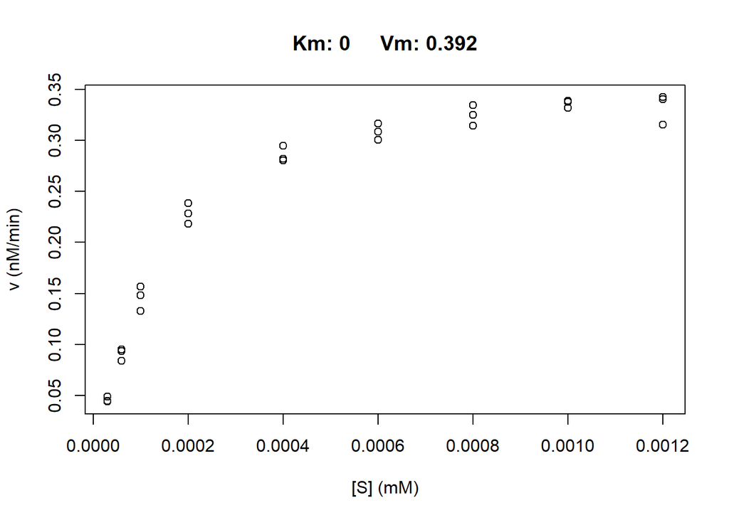

```
## $parameters
##    Km    Vm
## 0.000 0.392
##
## $data
## # A tibble: 27 × 3
##          S      v fitted_v
##      <dbl>  <dbl>    <dbl>
##  1 0.00003 0.0491    0.392
##  2 0.00003 0.0441    0.392
##  3 0.00003 0.0447    0.392
##  4 0.00006 0.0842    0.392
##  5 0.00006 0.095     0.392
##  6 0.00006 0.0936    0.392
##  7 0.0001  0.133     0.392
##  8 0.0001  0.148     0.392
##  9 0.0001  0.156     0.392
## 10 0.0002  0.218     0.392
## # ℹ 17 more rows
```

```r
library(renz)
#Gráfico con RENZ
dir.MM(datos_2[ , c(1,3)], unit_S = "mM", unit_v = "nM/min")
```

### GGPLOT

Ggplot es el paquete por excelencia para generar gráficos.

Para que se grafique con una curva de ajuste (línea de tendencia en Excel) se debe generar otro dataframe de estos datos y después incorporarlos en el gráfico.

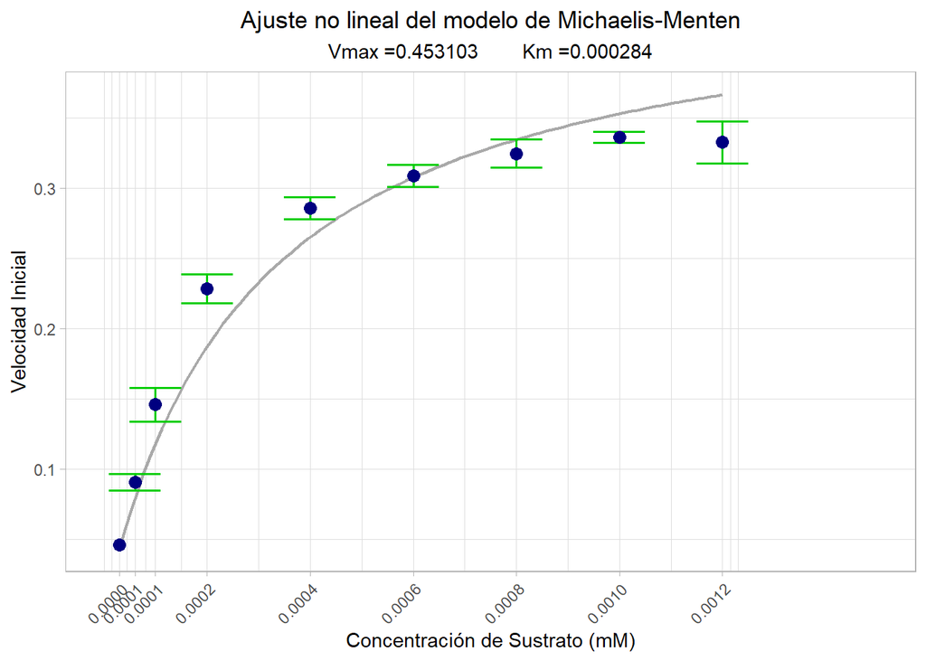

```r
# Visualizar gráfico con ggplot2
library(ggplot2)

# Crear un dataframe con la curva de ajuste
rango_concentracion <- seq(min(datos_2$Concentracion), max(datos_2$Concentracion), length = 100)
v0_pred <- (Vmax * rango_concentracion) / (Km + rango_concentracion)
predicciones <- data.frame(S = rango_concentracion,
                           v0_pred = v0_pred)
concentraciones_breaks <- unique(datos_2$Concentracion)

#Generar grafico con ggplot
ggplot(datos_2, aes(Concentracion, v0)) +
         geom_line(data = predicciones, aes(x = S, y = v0_pred), size = 0.8, colour = "darkgray") +
  stat_summary(fun.data = mean_sdl, fun.args = list(mult=1),
               geom="errorbar", color= "green3", width=0.0001, linewidth = 0.7) +
  stat_summary(fun.y=mean, geom="point", size = 3, color="navyblue") +
  scale_x_continuous(limits = c(0, 0.0015),
                     breaks = concentraciones_breaks,
                     labels = scales::number_format(accuracy = 0.0001)) +
  labs(title = "Ajuste no lineal del modelo de Michaelis-Menten",
              subtitle = paste0("Vmax =", round(Vmax, 6), "        Km =", round(Km, 6)),
              x = "Concentración de Sustrato (mM)", y = "Velocidad Inicial") +
         theme_light() + theme(plot.title = element_text(hjust = 0.5),
                                 plot.subtitle = element_text(hjust = 0.5),
                            axis.text.x = element_text(angle = 45, hjust = 1))
```

También se puede generar un plot más simple, sin necesidad de una paquetería como ggplot, con el siguiente código.

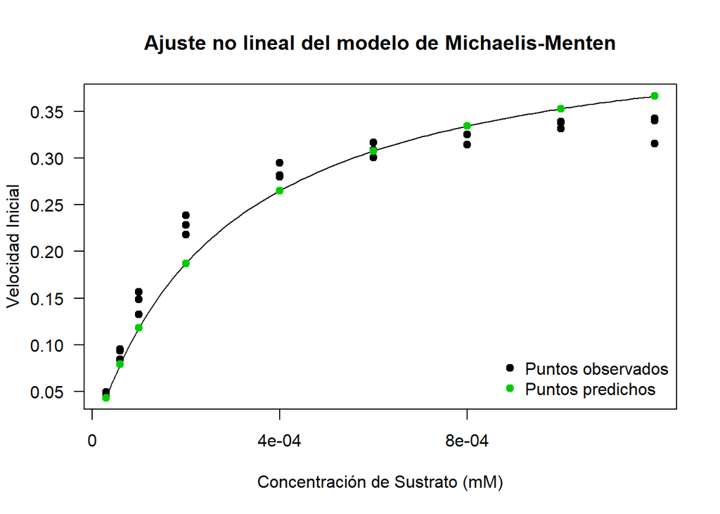

```r
plot(modelo_ajustado, log = '', type = "all",
     main = "Ajuste no lineal del modelo de Michaelis-Menten",
     xlab = "Concentración de Sustrato (mM)", ylab = "Velocidad Inicial", pch = 19)

points(datos_2$Concentracion, y = y_predicho,
       col = "green3", pch = 19)

legend("bottomright",
       legend = c("Puntos observados", "Puntos predichos"),
       pch = c(19, 19),
       col = c("black", "green3"),
       bty = "n")
```